# ANOVA

Species VS VE 0.8025 0.7233 rep 8.0000 11.0000

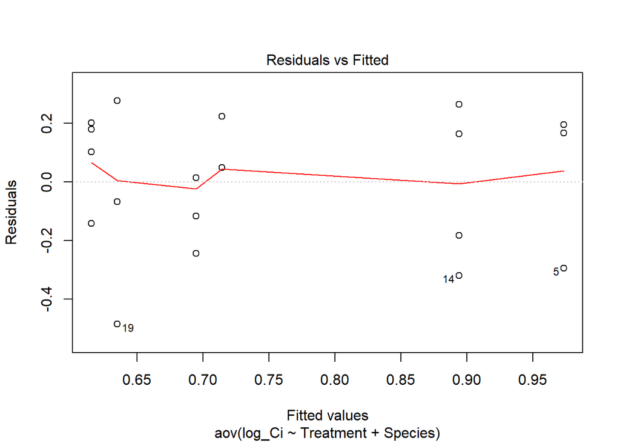

Levene’s Test for Homogeneity of Variance (center = median) Df F value Pr(>F) group 5 0.7515 0.5996 13  
**Amax (umol m-2 s-1) VS**

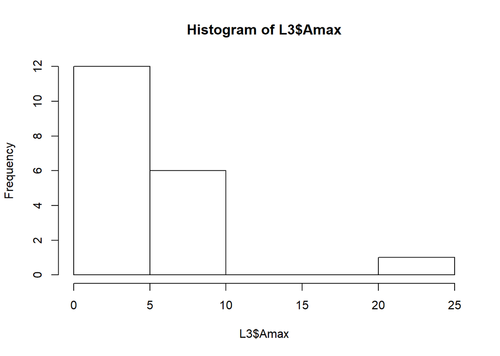

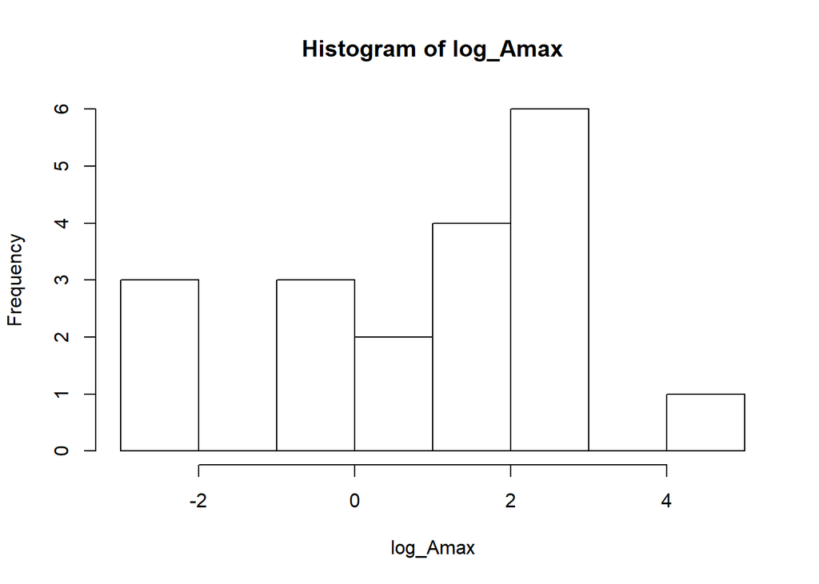

Df Sum Sq Mean Sq F value Pr(>F)  
Treatment 2 8.23 4.117 1.318 0.297  
Species 1 15.60 15.603 4.995 0.041 * Residuals 15 46.85 3.124  
— Signif. codes: 0 ‘**’ 0.001 ’**’ 0.01 ’’ 0.05 ‘.’ 0.1 ‘’ 1 Tukey multiple comparisons of means 95% family-wise confidence level

Fit: aov(formula = log_Amax ~ Treatment + Species, data = L3)

$Treatment diff lwr upr p adj 8%-4% -1.0248215 -3.478613 1.428970 0.5375333 16%-4% 0.5998851 -2.088109 3.287880 0.8328750 16%-8% 1.6247067 -1.063288 4.312701 0.2884086

$Species diff lwr upr p adj VE-VS -1.834864 -3.585241 -0.08448617 0.0411058

Tables of means Grand mean

1.081303

Treatment 4% 8% 16% 1.301 0.2762 1.901 rep 7.000 7.0000 5.000

Species VS VE 2.144 0.3087 rep 8.000 11.0000

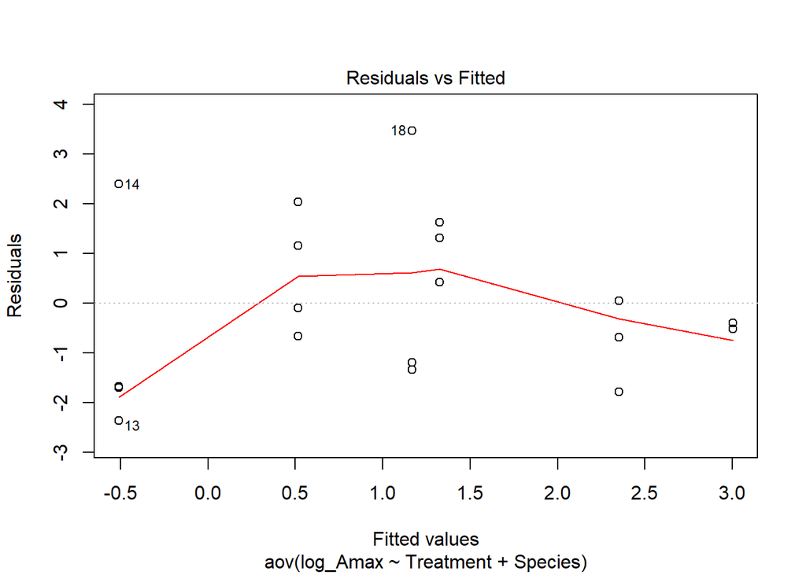

Levene’s Test for Homogeneity of Variance (center = median) Df F value Pr(>F) group 5 0.4115 0.8325 13  
**LSA (mm2)**

|  | Df | Sum Sq | Mean Sq | F value | Pr(>F) |
| --- | --- | --- | --- | --- | --- |
| Treatment | 2 | 0.02 | 0.01 | 0.44 | 0.6545 |
| Species | 1 | 0.03 | 0.03 | 1.02 | 0.3278 |
| Residuals | 15 | 0.41 | 0.03 |  |  |

**Ci:Ca**

|  | Df | Sum Sq | Mean Sq | F value | Pr(>F) |
| --- | --- | --- | --- | --- | --- |
| Treatment | 2 | 0.33 | 0.16 | 2.63 | 0.1052 |
| Species | 1 | 0.03 | 0.03 | 0.47 | 0.5043 |
| Residuals | 15 | 0.93 | 0.06 |  |  |

**Amax (umol m-2 s-1)**

|  | Df | Sum Sq | Mean Sq | F value | Pr(>F) |
| --- | --- | --- | --- | --- | --- |
| Treatment | 2 | 8.23 | 4.12 | 1.32 | 0.2969 |
| Species | 1 | 15.60 | 15.60 | 5.00 | 0.0410 |
| Residuals | 15 | 46.85 | 3.12 |  |  |